# Lab 03: Maximum Likelihood

## Fire Data

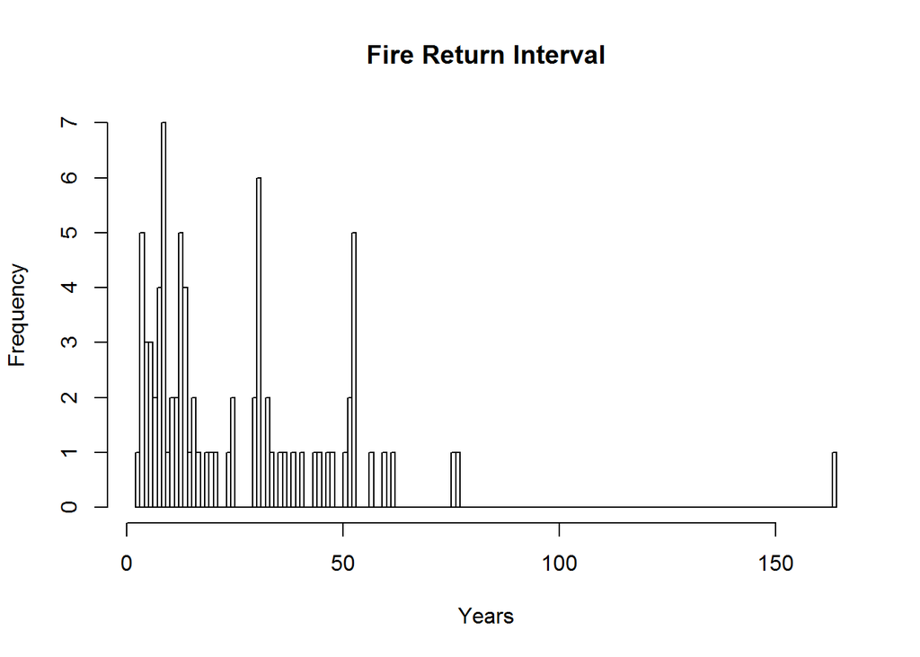

```r
### Fire scar example
fireintervals <- read.table("data/firescar.txt",header=TRUE)
firedata <- rep(fireintervals[,1],fireintervals[,2])
hist(firedata,nclass=max(firedata),xlab="Years",main="Fire Return Interval")
```

```r
summary(firedata)
```

```
##    Min. 1st Qu.  Median    Mean 3rd Qu.    Max.
##     2.0     9.0    16.0    26.1    36.8   164.0
```

Since the Weibull is a complex two-parameter model we’ll be solving for the MLE numerically rather than trying to find an analytical solution. As in the previous example, we do this by defining the negative log likelihood function that we want R to minimize.

```r
## define Weibull negative log likelihood
wlik <- function(param){
 -sum(dweibull(firedata, param[1], param[2], log = TRUE))
}
```

### Lab Questions

**Q 4:** Since the exponential is a special case of the Weibull, use the code from the first case study to solve for the exponential MLE (rho_mle) for the fire scar data.

**A:**

```r
fit <- optimize(lkexp,lower=0.0001,upper=2,maximum=F, dat=firedata)
fit$minimum
```

```
## [1] 0.03836
```

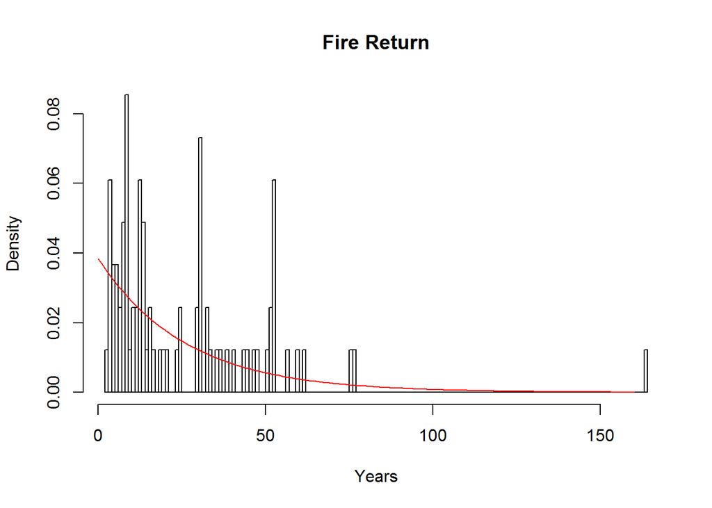

```r
hist(firedata,nclass=max(firedata),xlab="Years",main="Fire Return", freq=F)
lines(age, dexp(x = age, rate = fit$minimum,), col="red")
```

```r
param0 <- c(1.0,1/rho_mle)      ##initial condition for numerical optimization
wlik(param0)
```

```
## [1] 401.3
```

As in the first example, we will call upon one of R’s built in optimization functions to search parameter space and find the combination of parameters that has the lowest negative log likelihood.

```r
out <- optim(param0,wlik,lower=c(0.01,0.01), upper=c(100,100),method="L-BFGS-B")
out
```

[output not shown]

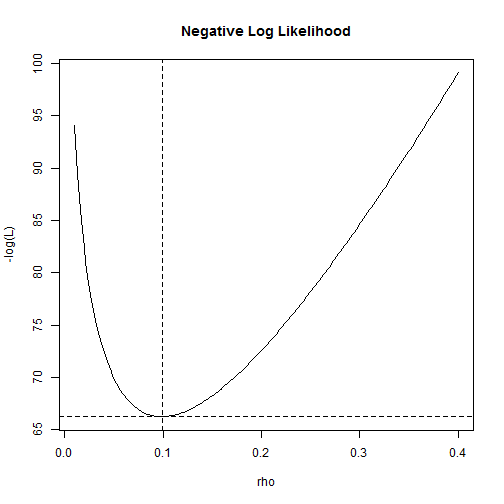

```r
## likelihood profile

rseq <- seq(0.01,0.4,length=200)        ## range of rho values on the x-axis

## Plot in the log domain:
plot(rseq,lkexp(rseq,dat),main="Negative Log Likelihood",
    xlab="rho",ylab="-log(L)",type='l')
abline(v=rho_mle,lty=2)
abline(h=lkexp(rho_mle,dat),lty=2)
```

### Lab Questions

**Q 1:** Include code to make a plot of the exponential PDF (with the MLE parameter estimate) on top of the histogram of the data.

**A:**

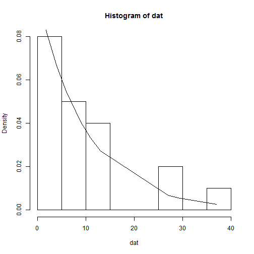

```r
hist(dat, freq=F)
# Sort  (dat,dexp(dat,rho_mle))
lines(sort(dat), dexp(sort(dat), rate = rho_mle))
```